# Comparitive Analysis of Crime in New York and Los Angeles

CMSC320 Final Project Hana Chitsaz, Vrunda Jasani, Sukhman Kaur

```
An Analysis of East Coast vs West Coast Criminal Data
 Crime in Los Angeles and New York (2010-2019)
```

Our Project In our course, CMSC320, we were able to create a final project on a topic of our choosing. We chose two separate datasets: Los Angeles and New York City. We decided to choose these locations as they are very popular cities on both the East and West coasts. In fact, they are the largest city on each coast (population-wise). We were able to find very large datasets that contained a lot of information about the different crimes that occurred throughout both locations and compare and contrast the information we found.

Data Sets: The following are the links to the New York City and LA datasets that we used:

New York City: https://data.cityofnewyork.us/Public-Safety/NYPD-Complaint-Data-Historic/qgea-i56i LA: https://data.lacity.org/Public-Safety/Crime-Data-from-2010-to-2019/63jg-8b9z

The New York City dataset contained over 7 million entries of data from 2006 to 2019. The Los Angeles dataset contained over 2 million entries of data from 2010-2019.

What Did We Do:

We were able to apply the skills we learned throughout this course to read, tidy, analyze, and compare and contrast our datasets. For this project, we were looking at multiple datasets to compare and contrast the information. We referred to the following link: https://medium.com/analytics-vidhya/comparison-of-two-data-sets-using-python-a24a6d8beb13 to get some tips on how to look and compare two sets of data. We also used many resources such as https://pandas.pydata.org/docs/user_guide/visualization.html and https://python-visualization.github.io/folium/ to create graphs and other visualizations to portray and show our analysis of the datasets. We used these resources as well as what we learned in class and through past projects to create our tutorial through the data science pipeline.

The first step is to import any and all required libraries. Here we import folium a library used to create convenient map API and the numpy and pandas library in order to use the numpy and pandas database functions which makes modifying, adjusting, and comparing the datasets much easier.

```python
import folium
import pandas
import numpy
```

# Data Collection

The next step is to import our datasets. We are looking to compare crime in major cities on the east coast vs the west coast. In order to do this we will look at case studies between New York and Los Angelos, the two biggest cities on each coast (by biggest we mean most populated).

We will start by importing the LA dataset. The crime dataset we are using for LA is provided by the local Los Angeles government for years 2010 to 2019. I have downloaded the csv file and uploaded them to Jupyter notebook so that we can read the file into a pandas data table using the pandas read_csv function.

```python
la = pandas.read_csv("LA_CrimeData_2010-2019.csv")
la
```

|  | DR_NO | Date Rptd | DATE OCC | TIME OCC | AREA | AREA NAME | Rpt Dist No | Part 1-2 | Crm Cd | Crm Cd Desc | ... | Status | Status Desc | Crm Cd 1 | Crm Cd 2 | Crm Cd 3 | Crm Cd 4 | LOCATION | Cross Street | LAT | LON |
| --- | --- | --- | --- | --- | --- | --- | --- | --- | --- | --- | --- | --- | --- | --- | --- | --- | --- | --- | --- | --- | --- |
| 0 | 1307355 | 02/20/2010 12:00:00 AM | 02/20/2010 12:00:00 AM | 1350 | 13 | Newton | 1385 | 2 | 900 | VIOLATION OF COURT ORDER | ... | AA | Adult Arrest | 900.0 | NaN | NaN | NaN | 300 E GAGE AV | NaN | 33.9825 | -118.2695 |
| 1 | 11401303 | 09/13/2010 12:00:00 AM | 09/12/2010 12:00:00 AM | 45 | 14 | Pacific | 1485 | 2 | 740 | VANDALISM - FELONY ($400 & OVER, ALL CHURCH VA... | ... | IC | Invest Cont | 740.0 | NaN | NaN | NaN | SEPULVEDA BL | MANCHESTER AV | 33.9599 | -118.3962 |
| 2 | 70309629 | 08/09/2010 12:00:00 AM | 08/09/2010 12:00:00 AM | 1515 | 13 | Newton | 1324 | 2 | 946 | OTHER MISCELLANEOUS CRIME | ... | IC | Invest Cont | 946.0 | NaN | NaN | NaN | 1300 E 21ST ST | NaN | 34.0224 | -118.2524 |
| 3 | 90631215 | 01/05/2010 12:00:00 AM | 01/05/2010 12:00:00 AM | 150 | 6 | Hollywood | 646 | 2 | 900 | VIOLATION OF COURT ORDER | ... | IC | Invest Cont | 900.0 | 998.0 | NaN | NaN | CAHUENGA BL | HOLLYWOOD BL | 34.1016 | -118.3295 |
| 4 | 100100501 | 01/03/2010 12:00:00 AM | 01/02/2010 12:00:00 AM | 2100 | 1 | Central | 176 | 1 | 122 | RAPE, ATTEMPTED | ... | IC | Invest Cont | 122.0 | NaN | NaN | NaN | 8TH ST | SAN PEDRO ST | 34.0387 | -118.2488 |
| ... | ... | ... | ... | ... | ... | ... | ... | ... | ... | ... | ... | ... | ... | ... | ... | ... | ... | ... | ... | ... | ... |
| 2060943 | 190608903 | 03/28/2019 12:00:00 AM | 03/28/2019 12:00:00 AM | 400 | 6 | Hollywood | 644 | 1 | 648 | ARSON | ... | IC | Invest Cont | 648.0 | NaN | NaN | NaN | 1400 N LA BREA AV | NaN | 34.0962 | -118.3490 |
| 2060944 | 190715222 | 08/15/2019 12:00:00 AM | 08/14/2019 12:00:00 AM | 1810 | 7 | Wilshire | 701 | 1 | 331 | THEFT FROM MOTOR VEHICLE - GRAND ($400 AND OVER) | ... | IC | Invest Cont | 331.0 | NaN | NaN | NaN | WILLOUGHBY AV | ORLANDO AV | 34.0871 | -118.3732 |
| 2060945 | 192004409 | 01/06/2019 12:00:00 AM | 01/06/2019 12:00:00 AM | 2100 | 20 | Olympic | 2029 | 2 | 930 | CRIMINAL THREATS - NO WEAPON DISPLAYED | ... | IC | Invest Cont | 930.0 | NaN | NaN | NaN | 6TH | VIRGIL | 34.0637 | -118.2870 |
| 2060946 | 191716777 | 10/17/2019 12:00:00 AM | 10/16/2019 12:00:00 AM | 1800 | 17 | Devonshire | 1795 | 1 | 420 | THEFT FROM MOTOR VEHICLE - PETTY ($950 & UNDER) | ... | IC | Invest Cont | 420.0 | NaN | NaN | NaN | 17200 NAPA ST | NaN | 34.2266 | -118.5085 |
| 2060947 | 190805435 | 02/01/2019 12:00:00 AM | 02/01/2019 12:00:00 AM | 1615 | 8 | West LA | 852 | 1 | 330 | BURGLARY FROM VEHICLE | ... | IC | Invest Cont | 330.0 | NaN | NaN | NaN | 1700 BARRY AV | NaN | 34.0420 | -118.4531 |

2060948 rows × 28 columns

Additionally, I downloaded the dataset for New York City crimes from NYPD open data, which shows the data of crimes in New York City from the years 2006 to 2019. I uploaded it to Jupyter notebook in order to be able to read it using the pandas read_csv function into a data table.

```python
ny = pandas.read_csv("NY_CrimeData_2006-2019.csv")
```

# Data Processing

Now we want to clean up the database so that we are only looking at data from the years 2010 to 2019 since our more restricted data set (the LA dataset) only has dates from 2010-2019. This way we will be comparing data from both sides of the coast during the same time period.

Let's start with LA. Although the data provided is from 2010-2019, we will run through the process of cleaning the dates for future use and in order to be extra careful. Here we run into one issue: the date and time are grouped into one column. We will split this column into day and month, year, and time.

Here we are parsing the column in the LA dataset using the str.split function and appending the time and whether it occured in the AM or PM together into a new time column in the database.

```python
la['TIME']=(la['DATE OCC'].str.split().str[1])+(la['DATE OCC'].str.split().str[2])
la['TIME']
```

```
0          12:00:00AM
1          12:00:00AM
2          12:00:00AM
3          12:00:00AM
4          12:00:00AM
              ...
2060943    12:00:00AM
2060944    12:00:00AM
2060945    12:00:00AM
2060946    12:00:00AM
2060947    12:00:00AM
Name: TIME, Length: 2060948, dtype: object
```

Now we will parse the same original LA dataset data-and-time column to create a new column for the date again using the str.split function.

```python
la['DATE']=(la['DATE OCC'].str.split().str[0])
la['DATE']
```

```
0          02/20/2010
1          09/12/2010
2          08/09/2010
3          01/05/2010
4          01/02/2010
              ...
2060943    03/28/2019
2060944    08/14/2019
2060945    01/06/2019
2060946    10/16/2019
2060947    02/01/2019
Name: DATE, Length: 2060948, dtype: object
```

In order to make our life easier, we will create a column to only hold the year, so that we can easily check to see which rows we would want to drop in order to only have data for 2010-2019. We use the str.split function to isolate the year and the astype function to change the year from being stored as a string to being stored as an int.

```python
la['YEAR']=la['DATE'].str.split('/').str[2]
la['YEAR']=la['YEAR'].astype(int)

la['YEAR']
```

```
0          2010
1          2010
2          2010
3          2010
4          2010
           ...
2060943    2019
2060944    2019
2060945    2019
2060946    2019
2060947    2019
Name: YEAR, Length: 2060948, dtype: int64
```

```python
la.head()
```

|  | DR_NO | Date Rptd | DATE OCC | TIME OCC | AREA | AREA NAME | Rpt Dist No | Part 1-2 | Crm Cd | Crm Cd Desc | ... | Crm Cd 2 | Crm Cd 3 | Crm Cd 4 | LOCATION | Cross Street | LAT | LON | TIME | DATE | YEAR |
| --- | --- | --- | --- | --- | --- | --- | --- | --- | --- | --- | --- | --- | --- | --- | --- | --- | --- | --- | --- | --- | --- |
| 0 | 1307355 | 02/20/2010 12:00:00 AM | 02/20/2010 12:00:00 AM | 1350 | 13 | Newton | 1385 | 2 | 900 | VIOLATION OF COURT ORDER | ... | NaN | NaN | NaN | 300 E GAGE AV | NaN | 33.9825 | -118.2695 | 12:00:00AM | 02/20/2010 | 2010 |
| 1 | 11401303 | 09/13/2010 12:00:00 AM | 09/12/2010 12:00:00 AM | 45 | 14 | Pacific | 1485 | 2 | 740 | VANDALISM - FELONY ($400 & OVER, ALL CHURCH VA... | ... | NaN | NaN | NaN | SEPULVEDA BL | MANCHESTER AV | 33.9599 | -118.3962 | 12:00:00AM | 09/12/2010 | 2010 |
| 2 | 70309629 | 08/09/2010 12:00:00 AM | 08/09/2010 12:00:00 AM | 1515 | 13 | Newton | 1324 | 2 | 946 | OTHER MISCELLANEOUS CRIME | ... | NaN | NaN | NaN | 1300 E 21ST ST | NaN | 34.0224 | -118.2524 | 12:00:00AM | 08/09/2010 | 2010 |
| 3 | 90631215 | 01/05/2010 12:00:00 AM | 01/05/2010 12:00:00 AM | 150 | 6 | Hollywood | 646 | 2 | 900 | VIOLATION OF COURT ORDER | ... | 998.0 | NaN | NaN | CAHUENGA BL | HOLLYWOOD BL | 34.1016 | -118.3295 | 12:00:00AM | 01/05/2010 | 2010 |
| 4 | 100100501 | 01/03/2010 12:00:00 AM | 01/02/2010 12:00:00 AM | 2100 | 1 | Central | 176 | 1 | 122 | RAPE, ATTEMPTED | ... | NaN | NaN | NaN | 8TH ST | SAN PEDRO ST | 34.0387 | -118.2488 | 12:00:00AM | 01/02/2010 | 2010 |

5 rows × 31 columns

Now that we have the columns for date and time parsed, we can remove all rows that do not fall under the year 2010-2019.

```python
la = la[la['YEAR'] >= 2010]
la = la[la['YEAR']<=2019]
la
```

|  | DR_NO | Date Rptd | DATE OCC | TIME OCC | AREA | AREA NAME | Rpt Dist No | Part 1-2 | Crm Cd | Crm Cd Desc | ... | Crm Cd 2 | Crm Cd 3 | Crm Cd 4 | LOCATION | Cross Street | LAT | LON | TIME | DATE | YEAR |
| --- | --- | --- | --- | --- | --- | --- | --- | --- | --- | --- | --- | --- | --- | --- | --- | --- | --- | --- | --- | --- | --- |
| 0 | 1307355 | 02/20/2010 12:00:00 AM | 02/20/2010 12:00:00 AM | 1350 | 13 | Newton | 1385 | 2 | 900 | VIOLATION OF COURT ORDER | ... | NaN | NaN | NaN | 300 E GAGE AV | NaN | 33.9825 | -118.2695 | 12:00:00AM | 02/20/2010 | 2010 |
| 1 | 11401303 | 09/13/2010 12:00:00 AM | 09/12/2010 12:00:00 AM | 45 | 14 | Pacific | 1485 | 2 | 740 | VANDALISM - FELONY ($400 & OVER, ALL CHURCH VA... | ... | NaN | NaN | NaN | SEPULVEDA BL | MANCHESTER AV | 33.9599 | -118.3962 | 12:00:00AM | 09/12/2010 | 2010 |
| 2 | 70309629 | 08/09/2010 12:00:00 AM | 08/09/2010 12:00:00 AM | 1515 | 13 | Newton | 1324 | 2 | 946 | OTHER MISCELLANEOUS CRIME | ... | NaN | NaN | NaN | 1300 E 21ST ST | NaN | 34.0224 | -118.2524 | 12:00:00AM | 08/09/2010 | 2010 |
| 3 | 90631215 | 01/05/2010 12:00:00 AM | 01/05/2010 12:00:00 AM | 150 | 6 | Hollywood | 646 | 2 | 900 | VIOLATION OF COURT ORDER | ... | 998.0 | NaN | NaN | CAHUENGA BL | HOLLYWOOD BL | 34.1016 | -118.3295 | 12:00:00AM | 01/05/2010 | 2010 |
| 4 | 100100501 | 01/03/2010 12:00:00 AM | 01/02/2010 12:00:00 AM | 2100 | 1 | Central | 176 | 1 | 122 | RAPE, ATTEMPTED | ... | NaN | NaN | NaN | 8TH ST | SAN PEDRO ST | 34.0387 | -118.2488 | 12:00:00AM | 01/02/2010 | 2010 |
| ... | ... | ... | ... | ... | ... | ... | ... | ... | ... | ... | ... | ... | ... | ... | ... | ... | ... | ... | ... | ... | ... |
| 2060943 | 190608903 | 03/28/2019 12:00:00 AM | 03/28/2019 12:00:00 AM | 400 | 6 | Hollywood | 644 | 1 | 648 | ARSON | ... | NaN | NaN | NaN | 1400 N LA BREA AV | NaN | 34.0962 | -118.3490 | 12:00:00AM | 03/28/2019 | 2019 |
| 2060944 | 190715222 | 08/15/2019 12:00:00 AM | 08/14/2019 12:00:00 AM | 1810 | 7 | Wilshire | 701 | 1 | 331 | THEFT FROM MOTOR VEHICLE - GRAND ($400 AND OVER) | ... | NaN | NaN | NaN | WILLOUGHBY AV | ORLANDO AV | 34.0871 | -118.3732 | 12:00:00AM | 08/14/2019 | 2019 |
| 2060945 | 192004409 | 01/06/2019 12:00:00 AM | 01/06/2019 12:00:00 AM | 2100 | 20 | Olympic | 2029 | 2 | 930 | CRIMINAL THREATS - NO WEAPON DISPLAYED | ... | NaN | NaN | NaN | 6TH | VIRGIL | 34.0637 | -118.2870 | 12:00:00AM | 01/06/2019 | 2019 |
| 2060946 | 191716777 | 10/17/2019 12:00:00 AM | 10/16/2019 12:00:00 AM | 1800 | 17 | Devonshire | 1795 | 1 | 420 | THEFT FROM MOTOR VEHICLE - PETTY ($950 & UNDER) | ... | NaN | NaN | NaN | 17200 NAPA ST | NaN | 34.2266 | -118.5085 | 12:00:00AM | 10/16/2019 | 2019 |
| 2060947 | 190805435 | 02/01/2019 12:00:00 AM | 02/01/2019 12:00:00 AM | 1615 | 8 | West LA | 852 | 1 | 330 | BURGLARY FROM VEHICLE | ... | NaN | NaN | NaN | 1700 BARRY AV | NaN | 34.0420 | -118.4531 | 12:00:00AM | 02/01/2019 | 2019 |

1833580 rows × 31 columns

Now we will repeat this process for the NYC database, specifically on the from date and time. We are not concerned about the duration of the crime. Additionally, we will relabel the time and date columns so that it mirrors that of the la database.

```python
#Here we are renaming the time column.
ny['TIME']= ny['CMPLNT_FR_TM']
ny['TIME']
```

```
0          17:30:00
1          16:31:00
2          18:45:00
3          01:00:00
4          21:41:00
             ...
7375988    03:00:00
7375989    23:30:00
7375990    08:30:00
7375991    07:30:00
7375992    11:30:00
Name: TIME, Length: 7375993, dtype: object
```

```python
ny['DATE']=(ny['CMPLNT_FR_DT'].str.split().str[0])
ny['DATE']
```

```
0          12/31/2019
1          12/29/2019
2          12/15/2019
3          12/28/2019
4          09/05/2008
              ...
7375988    12/17/2018
7375989    06/05/2018
7375990    02/10/2018
7375991    12/11/2018
7375992    05/10/2018
Name: DATE, Length: 7375993, dtype: object
```

Before we can continue with parsing the date data, we have to decide how we want to deal with missing date and time data. Because the dataset lacks context for us to be able to make a hypothesis about whem the missing crimes were committed and it doesn't make sense to assign an average date and time, we will remove the rows with missing date and time values. (Note: we did not run into this issue in the LA dataset because we were not missing and date and/or time data.

```python
ny = ny.dropna(subset = ['DATE'])
ny['YEAR']=ny['DATE'].str.split('/').str[2]

ny['YEAR']=ny['YEAR'].astype(int)
```

```python
shift_column = ny.pop('YEAR')
ny.insert(2, 'YEAR', shift_column)

ny = ny[ny['YEAR'] >= 2010]
```

```python
ny = ny[ny['YEAR'] <= 2019]
```

```python
ny.sort_values(by=['YEAR'])
```

|  | CMPLNT_NUM | CMPLNT_FR_DT | YEAR | CMPLNT_FR_TM | CMPLNT_TO_DT | CMPLNT_TO_TM | ADDR_PCT_CD | RPT_DT | KY_CD | OFNS_DESC | ... | Latitude | Longitude | Lat_Lon | PATROL_BORO | STATION_NAME | VIC_AGE_GROUP | VIC_RACE | VIC_SEX | TIME | DATE |
| --- | --- | --- | --- | --- | --- | --- | --- | --- | --- | --- | --- | --- | --- | --- | --- | --- | --- | --- | --- | --- | --- |
| 4247098 | 943935882 | 07/31/2010 | 2010 | 13:25:00 | NaN | NaN | 81.0 | 07/31/2010 | 341 | PETIT LARCENY | ... | 40.678807 | -73.920349 | (40.678806596, -73.920349394) | PATROL BORO BKLYN NORTH | NaN | NaN | UNKNOWN | D | 13:25:00 | 07/31/2010 |
| 5713397 | 908787989 | 06/11/2010 | 2010 | 22:58:00 | 06/12/2010 | 01:15:00 | 90.0 | 06/12/2010 | 107 | BURGLARY | ... | 40.712233 | -73.939579 | (40.71223312, -73.939578665) | PATROL BORO BKLYN NORTH | NaN | NaN | UNKNOWN | D | 22:58:00 | 06/11/2010 |
| 5713394 | 182138836 | 05/21/2010 | 2010 | 07:15:00 | 05/21/2010 | 07:20:00 | 24.0 | 05/21/2010 | 341 | PETIT LARCENY | ... | 40.793022 | -73.975826 | (40.793021598, -73.975826124) | PATROL BORO MAN NORTH | NaN | NaN | UNKNOWN | D | 07:15:00 | 05/21/2010 |
| 5713393 | 199409224 | 11/08/2010 | 2010 | 11:00:00 | 11/08/2010 | 11:20:00 | 103.0 | 11/08/2010 | 361 | OFF. AGNST PUB ORD SENSBLTY & | ... | 40.708801 | -73.778868 | (40.708800505, -73.778867617) | PATROL BORO QUEENS SOUTH | NaN | NaN | UNKNOWN | M | 11:00:00 | 11/08/2010 |
| 5713389 | 296887589 | 06/16/2010 | 2010 | 12:00:00 | NaN | NaN | 62.0 | 06/16/2010 | 361 | OFF. AGNST PUB ORD SENSBLTY & | ... | 40.612951 | -73.998377 | (40.612951089, -73.998377051) | PATROL BORO BKLYN SOUTH | NaN | 25-44 | WHITE | F | 12:00:00 | 06/16/2010 |
| ... | ... | ... | ... | ... | ... | ... | ... | ... | ... | ... | ... | ... | ... | ... | ... | ... | ... | ... | ... | ... | ... |
| 308058 | 971792461 | 05/12/2019 | 2019 | 12:00:00 | 05/13/2019 | 09:30:00 | 101.0 | 05/13/2019 | 578 | HARRASSMENT 2 | ... | 40.589920 | -73.788691 | (40.589920095000025, -73.78869103699996) | PATROL BORO QUEENS SOUTH | NaN | 25-44 | BLACK | F | 12:00:00 | 05/12/2019 |
| 308059 | 188995044 | 05/08/2019 | 2019 | 21:00:00 | 05/08/2019 | 22:00:00 | 32.0 | 05/09/2019 | 359 | OFFENSES AGAINST PUBLIC ADMINI | ... | 40.827547 | -73.937461 | (40.827546770000026, -73.93746131299997) | PATROL BORO MAN NORTH | NaN | 25-44 | BLACK | M | 21:00:00 | 05/08/2019 |
| 308060 | 381131952 | 05/08/2019 | 2019 | 00:30:00 | 05/08/2019 | 01:00:00 | 111.0 | 05/09/2019 | 344 | ASSAULT 3 & RELATED OFFENSES | ... | 40.748645 | -73.761884 | (40.748645340000046, -73.76188447799996) | PATROL BORO QUEENS NORTH | NaN | <18 | ASIAN / PACIFIC ISLANDER | F | 00:30:00 | 05/08/2019 |
| 308049 | 585321636 | 05/11/2019 | 2019 | 00:40:00 | 05/11/2019 | 01:10:00 | 109.0 | 05/11/2019 | 578 | HARRASSMENT 2 | ... | 40.766866 | -73.829068 | (40.76686626200007, -73.82906796799993) | PATROL BORO QUEENS NORTH | NaN | 25-44 | ASIAN / PACIFIC ISLANDER | M | 00:40:00 | 05/11/2019 |
| 0 | 394506329 | 12/31/2019 | 2019 | 17:30:00 | NaN | NaN | 32.0 | 12/31/2019 | 118 | DANGEROUS WEAPONS | ... | 40.820927 | -73.943324 | (40.82092679700002, -73.94332421899996) | PATROL BORO MAN NORTH | NaN | UNKNOWN | UNKNOWN | E | 17:30:00 | 12/31/2019 |

4846028 rows × 38 columns

To keep the datasets organized and less cluttered, we will remove any columns that we are not particularly interested in analyzing. Both datasets contained lots of information that are relevant to law enforcement, but not relevant to our analysis. Because of this, we want to clean and tidy our data so that our dataset is not noisey and overcrowded with data we won’t be using.

```python
#dropping unused columns in the la dataset
la=la.drop(columns=['Date Rptd','Vict Descent','Premis Desc','Weapon Used Cd','Premis Cd','Mocodes','DR_NO','Rpt Dist No','Part 1-2','Weapon Desc','Status','Status Desc','Crm Cd 1','Crm Cd 2','Crm Cd 3','Crm Cd 4','Cross Street'])
la
```

|  | DATE OCC | TIME OCC | AREA | AREA NAME | Crm Cd | Crm Cd Desc | Vict Age | Vict Sex | LOCATION | LAT | LON | TIME | DATE | YEAR |
| --- | --- | --- | --- | --- | --- | --- | --- | --- | --- | --- | --- | --- | --- | --- |
| 0 | 02/20/2010 12:00:00 AM | 1350 | 13 | Newton | 900 | VIOLATION OF COURT ORDER | 48 | M | 300 E GAGE AV | 33.9825 | -118.2695 | 12:00:00AM | 02/20/2010 | 2010 |
| 1 | 09/12/2010 12:00:00 AM | 45 | 14 | Pacific | 740 | VANDALISM - FELONY ($400 & OVER, ALL CHURCH VA... | 0 | M | SEPULVEDA BL | 33.9599 | -118.3962 | 12:00:00AM | 09/12/2010 | 2010 |
| 2 | 08/09/2010 12:00:00 AM | 1515 | 13 | Newton | 946 | OTHER MISCELLANEOUS CRIME | 0 | M | 1300 E 21ST ST | 34.0224 | -118.2524 | 12:00:00AM | 08/09/2010 | 2010 |
| 3 | 01/05/2010 12:00:00 AM | 150 | 6 | Hollywood | 900 | VIOLATION OF COURT ORDER | 47 | F | CAHUENGA BL | 34.1016 | -118.3295 | 12:00:00AM | 01/05/2010 | 2010 |
| 4 | 01/02/2010 12:00:00 AM | 2100 | 1 | Central | 122 | RAPE, ATTEMPTED | 47 | F | 8TH ST | 34.0387 | -118.2488 | 12:00:00AM | 01/02/2010 | 2010 |
| ... | ... | ... | ... | ... | ... | ... | ... | ... | ... | ... | ... | ... | ... | ... |
| 2060943 | 03/28/2019 12:00:00 AM | 400 | 6 | Hollywood | 648 | ARSON | 0 | X | 1400 N LA BREA AV | 34.0962 | -118.3490 | 12:00:00AM | 03/28/2019 | 2019 |
| 2060944 | 08/14/2019 12:00:00 AM | 1810 | 7 | Wilshire | 331 | THEFT FROM MOTOR VEHICLE - GRAND ($400 AND OVER) | 40 | M | WILLOUGHBY AV | 34.0871 | -118.3732 | 12:00:00AM | 08/14/2019 | 2019 |
| 2060945 | 01/06/2019 12:00:00 AM | 2100 | 20 | Olympic | 930 | CRIMINAL THREATS - NO WEAPON DISPLAYED | 46 | F | 6TH | 34.0637 | -118.2870 | 12:00:00AM | 01/06/2019 | 2019 |
| 2060946 | 10/16/2019 12:00:00 AM | 1800 | 17 | Devonshire | 420 | THEFT FROM MOTOR VEHICLE - PETTY ($950 & UNDER) | 0 | NaN | 17200 NAPA ST | 34.2266 | -118.5085 | 12:00:00AM | 10/16/2019 | 2019 |
| 2060947 | 02/01/2019 12:00:00 AM | 1615 | 8 | West LA | 330 | BURGLARY FROM VEHICLE | 33 | F | 1700 BARRY AV | 34.0420 | -118.4531 | 12:00:00AM | 02/01/2019 | 2019 |

1833580 rows × 14 columns

```python
#dropping unused columns in the NY dataset
ny=ny.drop(columns=['STATION_NAME','PATROL_BORO','HOUSING_PSA','HADEVELOPT','PARKS_NM','JURISDICTION_CODE','PREM_TYP_DESC','SUSP_RACE','SUSP_AGE_GROUP','JURIS_DESC','LOC_OF_OCCUR_DESC','LAW_CAT_CD','CRM_ATPT_CPTD_CD','PD_DESC','CMPLNT_NUM','CMPLNT_TO_DT','CMPLNT_TO_TM','ADDR_PCT_CD','RPT_DT','KY_CD','PD_CD','SUSP_SEX','TRANSIT_DISTRICT'])
ny
```

|  | CMPLNT_FR_DT | YEAR | CMPLNT_FR_TM | OFNS_DESC | BORO_NM | X_COORD_CD | Y_COORD_CD | Latitude | Longitude | Lat_Lon | VIC_AGE_GROUP | VIC_RACE | VIC_SEX | TIME | DATE |
| --- | --- | --- | --- | --- | --- | --- | --- | --- | --- | --- | --- | --- | --- | --- | --- |
| 0 | 12/31/2019 | 2019 | 17:30:00 | DANGEROUS WEAPONS | MANHATTAN | 999937.0 | 238365.0 | 40.820927 | -73.943324 | (40.82092679700002, -73.94332421899996) | UNKNOWN | UNKNOWN | E | 17:30:00 | 12/31/2019 |
| 1 | 12/29/2019 | 2019 | 16:31:00 | FORGERY | BRONX | 1022508.0 | 261990.0 | 40.885701 | -73.861640 | (40.885701406000074, -73.86164032499995) | UNKNOWN | UNKNOWN | E | 16:31:00 | 12/29/2019 |
| 2 | 12/15/2019 | 2019 | 18:45:00 | HARRASSMENT 2 | QUEENS | 1034178.0 | 209758.0 | 40.742281 | -73.819824 | (40.74228115600005, -73.81982408) | 25-44 | WHITE HISPANIC | F | 18:45:00 | 12/15/2019 |
| 3 | 12/28/2019 | 2019 | 01:00:00 | MISCELLANEOUS PENAL LAW | BRONX | 1026412.0 | 258211.0 | 40.875311 | -73.847545 | (40.87531145100007, -73.84754521099995) | UNKNOWN | UNKNOWN | E | 01:00:00 | 12/28/2019 |
| 5 | 12/27/2019 | 2019 | 22:00:00 | BURGLARY | MANHATTAN | 989665.0 | 201866.0 | 40.720759 | -73.980466 | (40.72075882100006, -73.98046642299995) | UNKNOWN | UNKNOWN | M | 22:00:00 | 12/27/2019 |
| ... | ... | ... | ... | ... | ... | ... | ... | ... | ... | ... | ... | ... | ... | ... | ... |
| 7375988 | 12/17/2018 | 2018 | 03:00:00 | VEHICLE AND TRAFFIC LAWS | BRONX | 1026486.0 | 262591.0 | 40.887333 | -73.847250 | (40.887332818, -73.847250013) | 25-44 | WHITE HISPANIC | F | 03:00:00 | 12/17/2018 |
| 7375989 | 06/05/2018 | 2018 | 23:30:00 | GRAND LARCENY OF MOTOR VEHICLE | BRONX | 1018029.0 | 240747.0 | 40.827414 | -73.877946 | (40.827414051, -73.877945775) | 25-44 | BLACK | M | 23:30:00 | 06/05/2018 |
| 7375990 | 02/10/2018 | 2018 | 08:30:00 | PETIT LARCENY | BRONX | 1010861.0 | 243330.0 | 40.834528 | -73.903836 | (40.834528146, -73.903836069) | 45-64 | BLACK | F | 08:30:00 | 02/10/2018 |
| 7375991 | 12/11/2018 | 2018 | 07:30:00 | ASSAULT 3 & RELATED OFFENSES | MANHATTAN | 1001322.0 | 235045.0 | 40.811812 | -73.938329 | (40.81181176, -73.938328651) | <18 | BLACK | M | 07:30:00 | 12/11/2018 |
| 7375992 | 05/10/2018 | 2018 | 11:30:00 | PETIT LARCENY | QUEENS | 1016138.0 | 214586.0 | 40.755616 | -73.884903 | (40.755616236, -73.884902833) | 25-44 | WHITE HISPANIC | F | 11:30:00 | 05/10/2018 |

4846028 rows × 15 columns

# Exploratory Analysis and Data Visualization

```python
# Text wrapping for the x lable of the graph

import textwrap
def wrap_labels(axs, width, break_long_words=False):
    labels = []
    for label in axs.get_xticklabels():
        text = label.get_text()
        labels.append(textwrap.fill(text, width=width,
                      break_long_words=break_long_words))
    axs.set_xticklabels(labels, rotation=0)
```

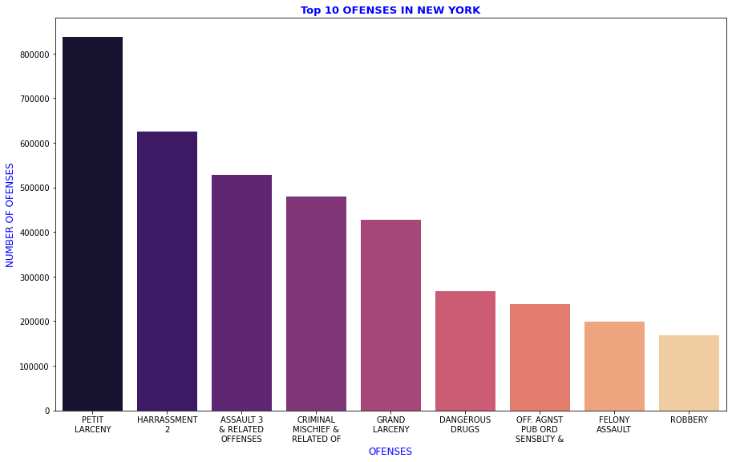

```python
# plotting bar graph of Top 10 ofenses in New York.

import seaborn as sns
import matplotlib.pyplot as plt


# Getting the list of all the crimes as x value and the number of each crime committed as y value
y = ny['OFNS_DESC'].value_counts().tolist()[0:9]
x = ny['OFNS_DESC'].value_counts().index.tolist()[0:9]



fig, axs = plt.subplots(figsize = (15, 9))
plot = sns.barplot(x, y, palette = 'magma')

axs.set_title('Top 10 OFENSES IN NEW YORK', color = 'b', fontsize = 13, weight = 'bold')
axs.set_xlabel('OFENSES', color = 'b', fontsize = 12)
axs.set_ylabel('NUMBER OF OFENSES', color = 'b', fontsize = 12)

# wrapping the text for x labels.
wrap_labels(axs, 10)
axs.figure

plt.show()
```

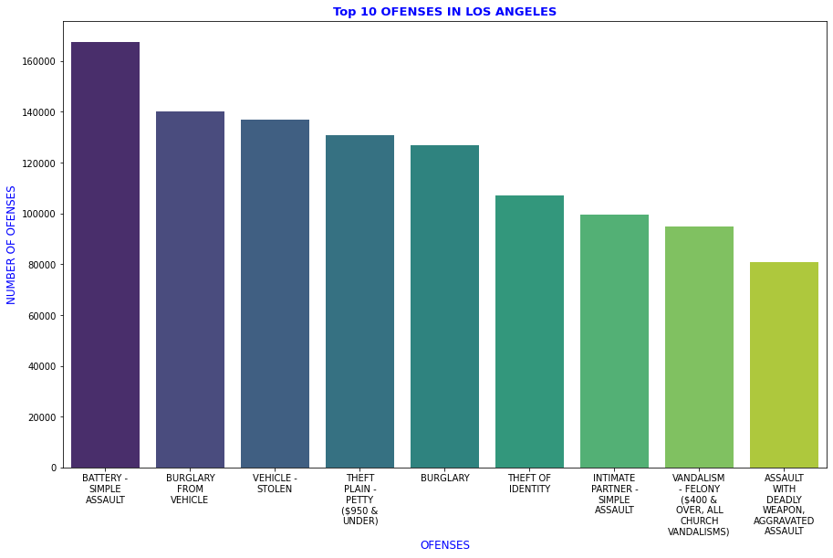

```python
# plotting bar graph of Top 10 ofenses in Los Angeles.


# Getting the list of all the crimes as x value and the number of each crime committed as y value
y = la['Crm Cd Desc'].value_counts().tolist()[0:9]
x = la['Crm Cd Desc'].value_counts().index.tolist()[0:9]



fig, axs = plt.subplots(figsize = (15, 9))
plot = sns.barplot(x, y, palette = 'viridis')

axs.set_title('Top 10 OFENSES IN LOS ANGELES', color = 'b', fontsize = 13, weight = 'bold')
axs.set_xlabel('OFENSES', color = 'b', fontsize = 12)
axs.set_ylabel('NUMBER OF OFENSES', color = 'b', fontsize = 12)



# wrapping the text for x labels.
wrap_labels(axs, 10)
axs.figure

plt.show()
```

Exploring More Exploratory Data Analysis:

```python
# getting the area names and number of crimes
ny['BORO_NM'].value_counts()
```

```
BROOKLYN         1445144
MANHATTAN        1161537
BRONX            1052413
QUEENS            959869
STATEN ISLAND     221308
Name: BORO_NM, dtype: int64
```

First we looked at the different areas that were present in the NY dataset. By running the code above, we found that the NY dataset had crime data for 5 different areas: Brooklyn, Manhattan, Bronx, Queens, and Staten Island. Therefore, we created 5 different scatterplots that showed and compared the number of crimes that happened in each of these areas.

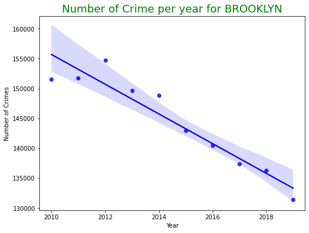

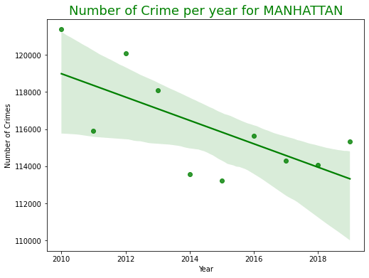

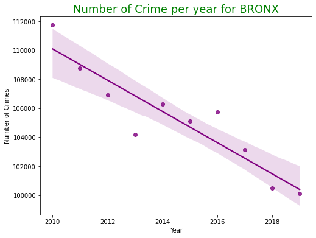

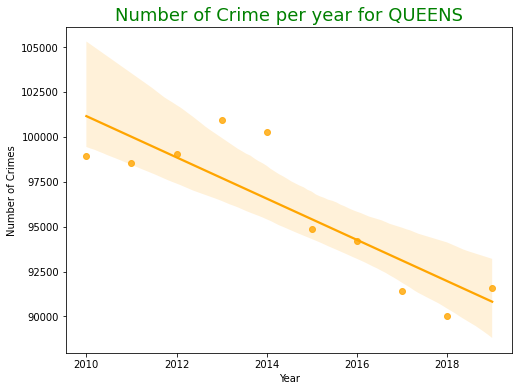

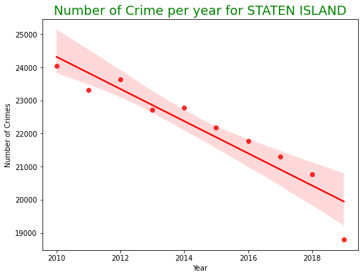

```python
yrs = [2010, 2011, 2012, 2013, 2014, 2015, 2016, 2017, 2018, 2019]

b = []
m = []
brx = []
q = []
sti = []



b.append(len(ny[(ny['BORO_NM']=='BROOKLYN') & (ny['YEAR'] == 2010)]))
b.append(len(ny[(ny['BORO_NM']=='BROOKLYN') & (ny['YEAR'] == 2011)]))
b.append(len(ny[(ny['BORO_NM']=='BROOKLYN') & (ny['YEAR'] == 2012)]))
b.append(len(ny[(ny['BORO_NM']=='BROOKLYN') & (ny['YEAR'] == 2013)]))
b.append(len(ny[(ny['BORO_NM']=='BROOKLYN') & (ny['YEAR'] == 2014)]))
b.append(len(ny[(ny['BORO_NM']=='BROOKLYN') & (ny['YEAR'] == 2015)]))
b.append(len(ny[(ny['BORO_NM']=='BROOKLYN') & (ny['YEAR'] == 2016)]))
b.append(len(ny[(ny['BORO_NM']=='BROOKLYN') & (ny['YEAR'] == 2017)]))
b.append(len(ny[(ny['BORO_NM']=='BROOKLYN') & (ny['YEAR'] == 2018)]))
b.append(len(ny[(ny['BORO_NM']=='BROOKLYN') & (ny['YEAR'] == 2019)]))

plt.figure(figsize = (8, 6))
sns.regplot(x = yrs, y = b,  color = 'blue')
plt.title("Number of Crime per year for BROOKLYN", color = 'green', fontsize = '18')
plt.xlabel("Year")
plt.ylabel("Number of Crimes")

m.append(len(ny[(ny['BORO_NM']=='MANHATTAN') & (ny['YEAR'] == 2010)]))
m.append(len(ny[(ny['BORO_NM']=='MANHATTAN') & (ny['YEAR'] == 2011)]))
m.append(len(ny[(ny['BORO_NM']=='MANHATTAN') & (ny['YEAR'] == 2012)]))
m.append(len(ny[(ny['BORO_NM']=='MANHATTAN') & (ny['YEAR'] == 2013)]))
m.append(len(ny[(ny['BORO_NM']=='MANHATTAN') & (ny['YEAR'] == 2014)]))
m.append(len(ny[(ny['BORO_NM']=='MANHATTAN') & (ny['YEAR'] == 2015)]))
m.append(len(ny[(ny['BORO_NM']=='MANHATTAN') & (ny['YEAR'] == 2016)]))
m.append(len(ny[(ny['BORO_NM']=='MANHATTAN') & (ny['YEAR'] == 2017)]))
m.append(len(ny[(ny['BORO_NM']=='MANHATTAN') & (ny['YEAR'] == 2018)]))
m.append(len(ny[(ny['BORO_NM']=='MANHATTAN') & (ny['YEAR'] == 2019)]))

plt.figure(figsize = (8, 6))
sns.regplot(x = yrs, y = m,  color = 'green')
plt.title("Number of Crime per year for MANHATTAN", color = 'green', fontsize = '18')
plt.xlabel("Year")
plt.ylabel("Number of Crimes")


brx.append(len(ny[(ny['BORO_NM']=='BRONX') & (ny['YEAR'] == 2010)]))
brx.append(len(ny[(ny['BORO_NM']=='BRONX') & (ny['YEAR'] == 2011)]))
brx.append(len(ny[(ny['BORO_NM']=='BRONX') & (ny['YEAR'] == 2012)]))
brx.append(len(ny[(ny['BORO_NM']=='BRONX') & (ny['YEAR'] == 2013)]))
brx.append(len(ny[(ny['BORO_NM']=='BRONX') & (ny['YEAR'] == 2014)]))
brx.append(len(ny[(ny['BORO_NM']=='BRONX') & (ny['YEAR'] == 2015)]))
brx.append(len(ny[(ny['BORO_NM']=='BRONX') & (ny['YEAR'] == 2016)]))
brx.append(len(ny[(ny['BORO_NM']=='BRONX') & (ny['YEAR'] == 2017)]))
brx.append(len(ny[(ny['BORO_NM']=='BRONX') & (ny['YEAR'] == 2018)]))
brx.append(len(ny[(ny['BORO_NM']=='BRONX') & (ny['YEAR'] == 2019)]))

plt.figure(figsize = (8, 6))
sns.regplot(x = yrs, y = brx,  color = 'purple')
plt.title("Number of Crime per year for BRONX", color = 'green', fontsize = '18')
plt.xlabel("Year")
plt.ylabel("Number of Crimes")


q.append(len(ny[(ny['BORO_NM']=='QUEENS') & (ny['YEAR'] == 2010)]))
q.append(len(ny[(ny['BORO_NM']=='QUEENS') & (ny['YEAR'] == 2011)]))
q.append(len(ny[(ny['BORO_NM']=='QUEENS') & (ny['YEAR'] == 2012)]))
q.append(len(ny[(ny['BORO_NM']=='QUEENS') & (ny['YEAR'] == 2013)]))
q.append(len(ny[(ny['BORO_NM']=='QUEENS') & (ny['YEAR'] == 2014)]))
q.append(len(ny[(ny['BORO_NM']=='QUEENS') & (ny['YEAR'] == 2015)]))
q.append(len(ny[(ny['BORO_NM']=='QUEENS') & (ny['YEAR'] == 2016)]))
q.append(len(ny[(ny['BORO_NM']=='QUEENS') & (ny['YEAR'] == 2017)]))
q.append(len(ny[(ny['BORO_NM']=='QUEENS') & (ny['YEAR'] == 2018)]))
q.append(len(ny[(ny['BORO_NM']=='QUEENS') & (ny['YEAR'] == 2019)]))

plt.figure(figsize = (8, 6))
sns.regplot(x = yrs, y = q,  color = 'orange')
plt.title("Number of Crime per year for QUEENS", color = 'green', fontsize = '18')
plt.xlabel("Year")
plt.ylabel("Number of Crimes")


sti.append(len(ny[(ny['BORO_NM']=='STATEN ISLAND') & (ny['YEAR'] == 2010)]))
sti.append(len(ny[(ny['BORO_NM']=='STATEN ISLAND') & (ny['YEAR'] == 2011)]))
sti.append(len(ny[(ny['BORO_NM']=='STATEN ISLAND') & (ny['YEAR'] == 2012)]))
sti.append(len(ny[(ny['BORO_NM']=='STATEN ISLAND') & (ny['YEAR'] == 2013)]))
sti.append(len(ny[(ny['BORO_NM']=='STATEN ISLAND') & (ny['YEAR'] == 2014)]))
sti.append(len(ny[(ny['BORO_NM']=='STATEN ISLAND') & (ny['YEAR'] == 2015)]))
sti.append(len(ny[(ny['BORO_NM']=='STATEN ISLAND') & (ny['YEAR'] == 2016)]))
sti.append(len(ny[(ny['BORO_NM']=='STATEN ISLAND') & (ny['YEAR'] == 2017)]))
sti.append(len(ny[(ny['BORO_NM']=='STATEN ISLAND') & (ny['YEAR'] == 2018)]))
sti.append(len(ny[(ny['BORO_NM']=='STATEN ISLAND') & (ny['YEAR'] == 2019)]))

plt.figure(figsize = (8, 6))
sns.regplot(x = yrs, y = sti,  color = 'red')
plt.title("Number of Crime per year for STATEN ISLAND", color = 'green', fontsize = '18')
plt.xlabel("Year")
plt.ylabel("Number of Crimes")
```

After running the code above, we were able to create 5 different scatterplots, one for each: Brooklyn, Manhattan, Bronx, Queens, and Staten Island. We color coded the points and the regression lines to make it easier to differenciate the data between each specific area. Each scatterplot represents the x-axis as the year (from 2010-2019) and the y-axis as the number of crimes that occurred in that specific area during that year. By adding the regression lines, we were able to compare the trends and slopes of the regression line for each area.

Analyzing this data for each area, we noticed that there was a general decrease in the number of crimes over time for each area. Although Brooklyn and Staten Island seemed to have a steeper regression line, all of their slopes seemed to be pretty similar to each other. They were negative and seemed to be decreasing at a rate that was similar among all five areas that we explored in the dataset. After looking at the range of the number of crimes for each area, we can also see that Brooklyn seems to have the largest maximum for the number of crimes committed across all the different areas at a range which goes all the way up to about 155,000. Staten Island seems to have the smallest maximum for the number of crimes committed across all the different areas at a range that only goes to 24,000-25,000. In general, when looking at the number of crimes from area to area, there is a general decrease in the number of crimes as the years increase or as time increases.

```python
# choosing top 5 areas of Los Angeles, in order to compare the crime rate with the areas of New York.
la['AREA NAME'].value_counts()[0:5]
```

```
Southwest      134705
77th Street    115816
Hollywood       98461
Central         97904
Harbor          91421
Name: AREA NAME, dtype: int64
```

Next, we decided to explore the LA the same way we did with New York previously. After looking at the dataset for LA, we found that there were a lot more areas represented and we wanted to make sure that we looked at 5 as we did in New York so we could compare and contrast the two different sets of plots. We decided to go with the top five represented areas within the LA dataset. We used the code above to choose the top five areas of LA (the ones that occurred the most frequently). Next, we created 5 different scatterplots that showed and compared the number of crimes that happened in each of these areas over time. The top five areas were: Southwest, 77th Street, Hollywood, Central, and Harbor.

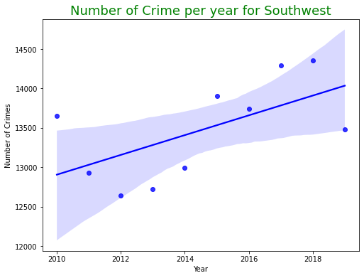

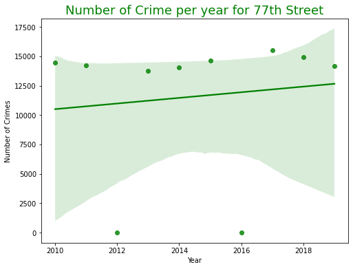

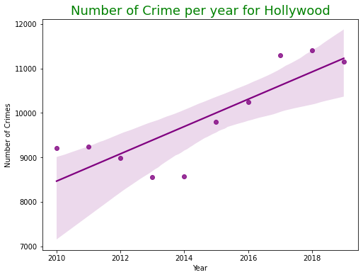

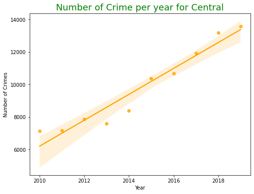

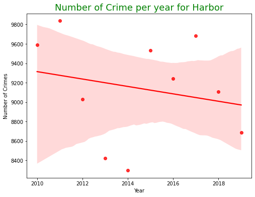

```python
# plotting a scateer plot with regression of number of crimes vs years for each area in New York

yrs = [2010, 2011, 2012, 2013, 2014, 2015, 2016, 2017, 2018, 2019]

sw = []
strt_77 = []
hlywd = []
cntrl = []
hrbr = []



sw.append(len(la[(la['AREA NAME']=='Southwest') & (la['YEAR'] == 2010)]))
sw.append(len(la[(la['AREA NAME']=='Southwest') & (la['YEAR'] == 2011)]))
sw.append(len(la[(la['AREA NAME']=='Southwest') & (la['YEAR'] == 2012)]))
sw.append(len(la[(la['AREA NAME']=='Southwest') & (la['YEAR'] == 2013)]))
sw.append(len(la[(la['AREA NAME']=='Southwest') & (la['YEAR'] == 2014)]))
sw.append(len(la[(la['AREA NAME']=='Southwest') & (la['YEAR'] == 2015)]))
sw.append(len(la[(la['AREA NAME']=='Southwest') & (la['YEAR'] == 2016)]))
sw.append(len(la[(la['AREA NAME']=='Southwest') & (la['YEAR'] == 2017)]))
sw.append(len(la[(la['AREA NAME']=='Southwest') & (la['YEAR'] == 2018)]))
sw.append(len(la[(la['AREA NAME']=='Southwest') & (la['YEAR'] == 2019)]))

plt.figure(figsize = (8, 6))
sns.regplot(x = yrs, y = sw,  color = 'blue')
plt.title("Number of Crime per year for Southwest", color = 'green', fontsize = '18')
plt.xlabel("Year")
plt.ylabel("Number of Crimes")

strt_77.append(len(la[(la['AREA NAME']=='77th Street') & (la['YEAR'] == 2010)]))
strt_77.append(len(la[(la['AREA NAME']=='77th Street') & (la['YEAR'] == 2011)]))
strt_77.append(len(la[(la['AREA NAME']=='77th Street') & (la['YEAR'] == 2012)]))
strt_77.append(len(la[(la['AREA NAME']=='77th Street') & (la['YEAR'] == 2013)]))
strt_77.append(len(la[(la['AREA NAME']=='77th Street') & (la['YEAR'] == 2014)]))
strt_77.append(len(la[(la['AREA NAME']=='77th Street') & (la['YEAR'] == 2015)]))
strt_77.append(len(la[(la['AREA NAME']=='77th Street') & (la['YEAR'] == 2016)]))
strt_77.append(len(la[(la['AREA NAME']=='77th Street') & (la['YEAR'] == 2017)]))
strt_77.append(len(la[(la['AREA NAME']=='77th Street') & (la['YEAR'] == 2018)]))
strt_77.append(len(la[(la['AREA NAME']=='77th Street') & (la['YEAR'] == 2019)]))


plt.figure(figsize = (8, 6))
sns.regplot(x = yrs, y = strt_77,  color = 'green')
plt.title("Number of Crime per year for 77th Street", color = 'green', fontsize = '18')
plt.xlabel("Year")
plt.ylabel("Number of Crimes")


hlywd.append(len(la[(la['AREA NAME']=='Hollywood') & (la['YEAR'] == 2010)]))
hlywd.append(len(la[(la['AREA NAME']=='Hollywood') & (la['YEAR'] == 2011)]))
hlywd.append(len(la[(la['AREA NAME']=='Hollywood') & (la['YEAR'] == 2012)]))
hlywd.append(len(la[(la['AREA NAME']=='Hollywood') & (la['YEAR'] == 2013)]))
hlywd.append(len(la[(la['AREA NAME']=='Hollywood') & (la['YEAR'] == 2014)]))
hlywd.append(len(la[(la['AREA NAME']=='Hollywood') & (la['YEAR'] == 2015)]))
hlywd.append(len(la[(la['AREA NAME']=='Hollywood') & (la['YEAR'] == 2016)]))
hlywd.append(len(la[(la['AREA NAME']=='Hollywood') & (la['YEAR'] == 2017)]))
hlywd.append(len(la[(la['AREA NAME']=='Hollywood') & (la['YEAR'] == 2018)]))
hlywd.append(len(la[(la['AREA NAME']=='Hollywood') & (la['YEAR'] == 2019)]))


plt.figure(figsize = (8, 6))
sns.regplot(x = yrs, y = hlywd,  color = 'purple')
plt.title("Number of Crime per year for Hollywood", color = 'green', fontsize = '18')
plt.xlabel("Year")
plt.ylabel("Number of Crimes")


cntrl.append(len(la[(la['AREA NAME']=='Central') & (la['YEAR'] == 2010)]))
cntrl.append(len(la[(la['AREA NAME']=='Central') & (la['YEAR'] == 2011)]))
cntrl.append(len(la[(la['AREA NAME']=='Central') & (la['YEAR'] == 2012)]))
cntrl.append(len(la[(la['AREA NAME']=='Central') & (la['YEAR'] == 2013)]))
cntrl.append(len(la[(la['AREA NAME']=='Central') & (la['YEAR'] == 2014)]))
cntrl.append(len(la[(la['AREA NAME']=='Central') & (la['YEAR'] == 2015)]))
cntrl.append(len(la[(la['AREA NAME']=='Central') & (la['YEAR'] == 2016)]))
cntrl.append(len(la[(la['AREA NAME']=='Central') & (la['YEAR'] == 2017)]))
cntrl.append(len(la[(la['AREA NAME']=='Central') & (la['YEAR'] == 2018)]))
cntrl.append(len(la[(la['AREA NAME']=='Central') & (la['YEAR'] == 2019)]))



plt.figure(figsize = (8, 6))
sns.regplot(x = yrs, y = cntrl,  color = 'orange')
plt.title("Number of Crime per year for Central", color = 'green', fontsize = '18')
plt.xlabel("Year")
plt.ylabel("Number of Crimes")

hrbr.append(len(la[(la['AREA NAME']=='Harbor') & (la['YEAR'] == 2010)]))
hrbr.append(len(la[(la['AREA NAME']=='Harbor') & (la['YEAR'] == 2011)]))
hrbr.append(len(la[(la['AREA NAME']=='Harbor') & (la['YEAR'] == 2012)]))
hrbr.append(len(la[(la['AREA NAME']=='Harbor') & (la['YEAR'] == 2013)]))
hrbr.append(len(la[(la['AREA NAME']=='Harbor') & (la['YEAR'] == 2014)]))
hrbr.append(len(la[(la['AREA NAME']=='Harbor') & (la['YEAR'] == 2015)]))
hrbr.append(len(la[(la['AREA NAME']=='Harbor') & (la['YEAR'] == 2016)]))
hrbr.append(len(la[(la['AREA NAME']=='Harbor') & (la['YEAR'] == 2017)]))
hrbr.append(len(la[(la['AREA NAME']=='Harbor') & (la['YEAR'] == 2018)]))
hrbr.append(len(la[(la['AREA NAME']=='Harbor') & (la['YEAR'] == 2019)]))



plt.figure(figsize = (8, 6))
sns.regplot(x = yrs, y = hrbr,  color = 'red')
plt.title("Number of Crime per year for Harbor", color = 'green', fontsize = '18')
plt.xlabel("Year")
plt.ylabel("Number of Crimes")
```

After running the code above, we were able to create 5 different scatterplots, one for each: Southwest, 77th Street, Hollywood, Central, and Harbor. We color coded the points and the regression lines to make it easier to differenciate the data between each specific area. Each scatterplot represents the x-axis as the year (from 2010-2019) and the y-axis as the number of crimes that occurred in that specific area during that year. By adding the regression lines, we were able to compare the trends and slopes of the regression line for each area.

Now performing, further visualizations on the data

```python
map_LA = folium.Map(location=[34.0522, -118.2437], zoom_start=11)
red_2019 = 0
blue_2018 = 0
green_2017 = 0
for i,row in la.iterrows():
    #Burglary
    if row["YEAR"] == 2019 and row['Crm Cd Desc'] == "CRIMINAL HOMICIDE" and row['Vict Sex'] == "F":
        folium.Marker(location=[row["LAT"], row["LON"]],
            icon=folium.Icon(color='red')).add_to(map_LA)
        red_2019 += 1
    if row["YEAR"] == 2018 and row['Crm Cd Desc'] == "CRIMINAL HOMICIDE" and row['Vict Sex'] == "F":
        folium.Marker(location=[row["LAT"], row["LON"]],
            icon=folium.Icon(color='darkblue')).add_to(map_LA)
        blue_2018 += 1
    if row["YEAR"] == 2017 and row['Crm Cd Desc'] == "CRIMINAL HOMICIDE" and row['Vict Sex'] == "F":
        folium.Marker(location=[row["LAT"], row["LON"]],
            icon=folium.Icon(color='green')).add_to(map_LA)
        green_2017 += 1

print("Criminal Homicide in Females in 2019 : ", red_2019)
print("Criminal Homicide in Females in 2018 : ", blue_2018)
print("Criminal Homicide in Females in 2017 : ", green_2017)
map_LA
```

```
Criminal Homicide in Females in 2019 :  34
Criminal Homicide in Females in 2018 :  48
Criminal Homicide in Females in 2017 :  32
```

Make this Notebook Trusted to load map: File -> Trust Notebook

[interactive chart not shown]

```python
map_NY = folium.Map(location=[40.8028, -73.9060], zoom_start=11)
red_2019 = 0
blue_2018 = 0
green_2017 = 0
for i,row in ny.iterrows():
    #Burglary
    if row["YEAR"] == 2019 and row['OFNS_DESC'] == "MURDER & NON-NEGL. MANSLAUGHTER" and row['VIC_SEX'] == "F":
        folium.Marker(location=[row["Latitude"], row["Longitude"]],
            icon=folium.Icon(color='red')).add_to(map_NY)
        red_2019 += 1
    if row["YEAR"] == 2018 and row['OFNS_DESC'] == "MURDER & NON-NEGL. MANSLAUGHTER" and row['VIC_SEX'] == "F":
        folium.Marker(location=[row["Latitude"], row["Longitude"]],
            icon=folium.Icon(color='darkblue')).add_to(map_NY)
        blue_2018 += 1
    if row["YEAR"] == 2017 and row['OFNS_DESC'] == "MURDER & NON-NEGL. MANSLAUGHTER" and row['VIC_SEX'] == "F":
        folium.Marker(location=[row["Latitude"], row["Longitude"]],
            icon=folium.Icon(color='green')).add_to(map_NY)
        green_2017 += 1

print("Criminal Homicide in  Females in 2019 : ", red_2019)
print("Criminal Homicide in  Females in 2018 : ", blue_2018)
print("Criminal Homicide in  Females in 2017 : ", green_2017)
map_NY
```

```
Criminal Homicide in  Females in 2019 :  57
Criminal Homicide in  Females in 2018 :  53
Criminal Homicide in  Females in 2017 :  61
```

Make this Notebook Trusted to load map: File -> Trust Notebook

[interactive chart not shown]

Here we are using the folium library to create interactive maps. These maps show the clustering of homicides with female victims over the past three years. The benefit of using a map to display this data as opposed to a bar graph, pie chart, or scatter plot is that the map allows the user to see clusters of occurrences that happened in different locations around the city in a cleaner way than if we had just listed the addresses or area codes. The red markers indicate homicides with female victims that happened in 2019, and blue and green indicate the same for 2018 and 2017, respectively. Another benefit of using the map to display and analyze this data is that the user can zoom in or out of different areas of interest on the map, depending on what you are trying to learn from the data. For example, if you want to see an overview or get a general idea of where most homicides occur with female victims in La, you look at the zoomed out version of the map. However, after seeing the cluster of homicides in the mid to southern area of LA, you have the ability to zoom in and get a better understanding of what years homicides were most common and in what areas. In this case, 2018 had the most homicides with female victims, and from the map you can see a cluster of almost entirely 2018 homicides in South Los Angeles. Similarly for the NYC dataset, the map shows clusters of where the homicides occur and what areas with what years were most common. For example, south NYC saw much less homicides in 2018 compared to 2019 and 2017.

# Analysis and Hypothesis Testing

Now, we will perform hypothesis testing for LA and New York for crime rate vs years. We will first get the number for crimes for each year. Then I got the population of each city for ech year from the https://www.health.ny.gov/statistics/vital_statistics/2018/table02.htm. Then we divide the value of number of crimes for each year by the population of that year and multiply by 100 in order to obtain the crime rate. Then we plot those values and get a scatter plot with a regresion line.

```python
# For New York City

# Get the number of crimes for each year in a list
c_ny = ny['YEAR'].value_counts().to_list()
population_ny = [8175133, 8336697 ,8244910, 8405837, 8491079, 8550405, 8537673, 8622698, 8398748, 8498748]


# Get the years in a list
yrs_ny = ny['YEAR'].value_counts().index.to_list()
y_n = yrs_ny

print(len(yrs_ny))


# Calculate the crime rate (number of crimes per year/ population of that year) * 100
# We multiply by 100 to get the rate.
crime_rate_ny = [(m/n) * 100 for m, n in zip(c_ny, population_ny)]
print(len(crime_rate_ny))
c_n = crime_rate_ny
```

```
10
10
```

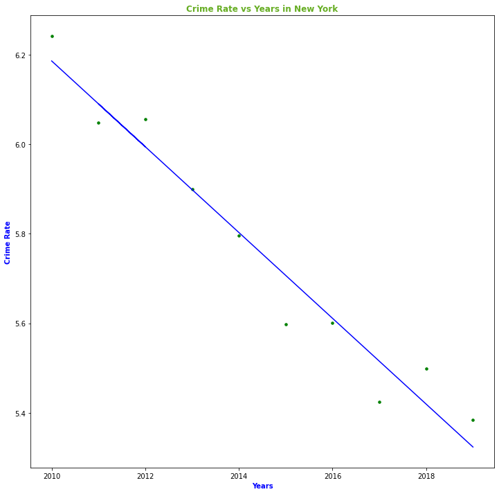

```python
# plot a scatter plot with regression line for the years vs crime rate

fig, axs = plt.subplots( figsize=(12,12) )
axs.scatter(yrs_ny, crime_rate_ny, marker = '.', s = 50,color = 'green')
slope, y = numpy.polyfit(yrs_ny, crime_rate_ny, 1)
plt.plot(
    yrs_ny,
    numpy.multiply(slope, yrs_ny) + y, color = 'b')
    # labeling axes and giving a title to graph
plt.xlabel("Years", fontweight = "bold")
axs.xaxis.label.set_color('Blue')
plt.ylabel("Crime Rate", fontweight = "bold")
axs.yaxis.label.set_color('Blue')
plt.title(f"Crime Rate vs Years in New York", fontweight = "bold", color = '#66ad23')
```

```python
# For Los Angeles

# Get the number of crimes for each year in a list
c_la = la['YEAR'].value_counts()
population_la = [3982002, 3990456, 3943215, 3795370, 3821136, 3913260, 3883916, 3969262, 3852532, 3979576]

# Get the years in a list
yrs_la = la['YEAR'].value_counts().index.to_list()
y_l = yrs_la

# Calculate the crime rate (number of crimes per year/ population of that year) * 100
# We multiply by 100 to get the rate.
crime_rate_la = [(m/n) * 100 for m, n in zip(c_la, population_la)]
c_l = crime_rate_la
```

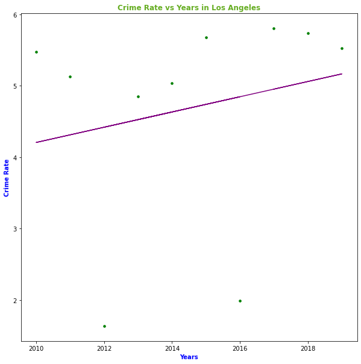

```python
# plot a scatter plot with regression line for the years vs crime rate

fig, axs = plt.subplots( figsize=(10,10) )
axs.scatter(yrs_la, crime_rate_la, marker = '.', s = 50,color = 'green')
slope, y = numpy.polyfit(yrs_la, crime_rate_la, 1)
plt.plot(
    yrs_la,
    numpy.multiply(slope, yrs_la) + y, color = 'purple')
    # labeling axes and giving a title to graph
plt.xlabel("Years", fontweight = "bold")
axs.xaxis.label.set_color('Blue')
plt.ylabel("Crime Rate", fontweight = "bold")
axs.yaxis.label.set_color('Blue')
plt.title(f"Crime Rate vs Years in Los Angeles", fontweight = "bold", color = '#66ad23')
```

```python
from scipy.stats import spearmanr

df = pandas.DataFrame()

df['Years'] = y_l
df['Crime_Rate_LA'] = c_l
df['Crime_Rate_NY'] = c_n


s, p_value = spearmanr(df.Years.values, df.Crime_Rate_LA.values)
print('p value and correlation for LA')
print('Statistic = %.4f, p = %.4f' % (s , p_value))
if p_value > 0.05:
    print('No correlation', p_value)
else:
    print('Correlated', p_value)

print("----------------------")
s, p_value = spearmanr(df.Years.values, df.Crime_Rate_NY.values)
print('p value and correlation for NY')
print('Statistic = %.4f, p = %.4f' % (s , p_value))
if p_value > 0.05:
    print('No correlation', p_value)
else:
    print('Correlated', p_value)
```

```
p value and correlation for LA
Statistic = 0.5030, p = 0.1383
No correlation 0.13833369839449197
----------------------
p value and correlation for NY
Statistic = 0.6242, p = 0.0537
No correlation 0.053717767217167395
```

Now, we will compare the New York and Los Angeles graphs together.

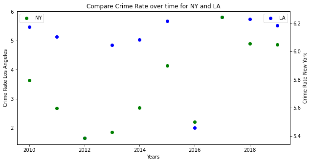

```python
# crime_rate_ny.append(5.39967683939827)

df['Years'] = y_l
df['Crime_Rate_LA'] = c_l
df['Crime_Rate_NY'] = c_n

# x-axis
x = y_l

# y-axis values
y1 = c_l

# secondary y-axis values
y2 = c_n

# plotting figures by creating aexs object
# using subplots() function


fig = plt.figure(figsize=(10,5))
ax = fig.add_subplot(111)
ax2 = ax.twinx()

ax.scatter(x, y1, c="b", label = 'LA')
ax2.scatter(x, y2, c="g", label = 'NY')

ax.set_title("Compare Crime Rate over time for NY and LA")
ax.set_xlabel("Years")
ax.set_ylabel("Crime Rate Los Angeles")
ax2.set_ylabel("Crime Rate New York")


ax.legend(loc = 1)
ax2.legend(loc = 2)
```

Hypothesis Testing: In order to complete the hypothesis testing of our project, we first needed to come up with and create a null hypothesis. In order to do this, we wanted to compare two different columns: year and crime. We decided to compare and see whether or not the number of crimes committed is correlated to the year that the crime was comitted. Our null hypothesis was: there is no correlation between time (in years) and the number of crimes committed.

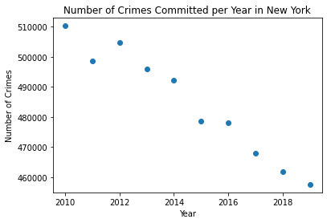

```python
#number of crimes vs year with regression analysis & hypothesis testing
#NY
x = ny['YEAR'].value_counts().tolist()
y = ny['YEAR'].value_counts().index.tolist()

s = x
t = y
import matplotlib.pyplot as plt
plt.scatter(y, x)
plt.title('Number of Crimes Committed per Year in New York')
plt.xlabel("Year")
plt.ylabel("Number of Crimes")
plt.show()
```

In order to analyze year vs. crime, we decided to create a visual to show the different years vs. the number of crimes that were committed in NY. The x-axis represents the year that the crime was committed and the y axis represents the number of crimes comitted in that year. Looking at the scatter plot, there seems to be a big range between the number of crimes committed over time.

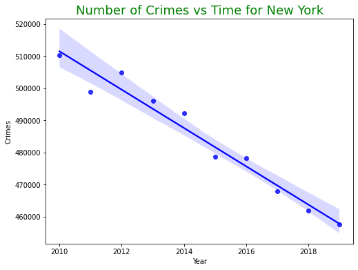

```python
import seaborn as sns
from sklearn import linear_model
from statsmodels.formula.api import ols

df = pandas.DataFrame()

df['Crimes'] = s
df['Year'] = t


plt.figure(figsize = (8, 6))
sns.regplot(x = "Year", y = "Crimes", data = df, color = 'blue')
plt.title('Number of Crimes vs Time for New York',color = 'green', fontsize = '18')
plt.xlabel("Year")
plt.ylabel("Crimes")
```

This scatterplot represents the spread of the number of crimes per year from 2010 to 2019. After plotting our regression line, we were able continue onto the next step. Next we decided to print out the regression summary to actually see what the slope and intercepts were.

```python
regression = ols(formula = 'Crimes ~ Year', data = df).fit()
print(regression.summary())
```

```
                            OLS Regression Results
==============================================================================
Dep. Variable:                 Crimes   R-squared:                       0.960
Model:                            OLS   Adj. R-squared:                  0.955
Method:                 Least Squares   F-statistic:                     190.7
Date:                Mon, 16 May 2022   Prob (F-statistic):           7.31e-07
Time:                        17:07:41   Log-Likelihood:                -95.820
No. Observations:                  10   AIC:                             195.6
Df Residuals:                       8   BIC:                             196.2
Df Model:                           1
Covariance Type:            nonrobust
==============================================================================
                 coef    std err          t      P>|t|      [0.025      0.975]
------------------------------------------------------------------------------
Intercept    1.25e+07    8.7e+05     14.365      0.000    1.05e+07    1.45e+07
Year       -5963.6970    431.899    -13.808      0.000   -6959.658   -4967.736
==============================================================================
Omnibus:                        0.096   Durbin-Watson:                   3.107
Prob(Omnibus):                  0.953   Jarque-Bera (JB):                0.263
Skew:                          -0.170   Prob(JB):                        0.877
Kurtosis:                       2.283   Cond. No.                     1.41e+06
==============================================================================

Notes:
[1] Standard Errors assume that the covariance matrix of the errors is correctly specified.
[2] The condition number is large, 1.41e+06. This might indicate that there are
strong multicollinearity or other numerical problems.
```

Hypothesis Testing: In order to complete the hypothesis testing of our project, we first needed to come up with and create a null hypothesis. In order to do this, we wanted to compare two different columns: year and crime. We decided to compare and see whether or not the number of crimes committed is correlated to the year that the crime was comitted. Our null hypothesis was: there is no correlation between time (in years) and the number of crimes committed.

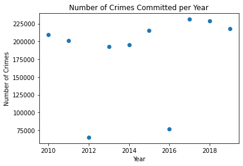

```python
import matplotlib.pyplot as plt

x = la['YEAR'].value_counts().tolist()
y = la['YEAR'].value_counts().index.tolist()

s = x
t = y
import matplotlib.pyplot as plt
plt.scatter(y, x)
plt.title('Number of Crimes Committed per Year')
plt.xlabel("Year")
plt.ylabel("Number of Crimes")
plt.show()
```

In order to analyze year vs. crime, we decided to create a visual to show the different years vs. the number of crimes that were committed in LA. The x-axis represents the year that the crime was committed and the y axis represents the number of crimes comitted in that year. Looking at the scatter plot, there seems to be a big range between the number of crimes committed over time.

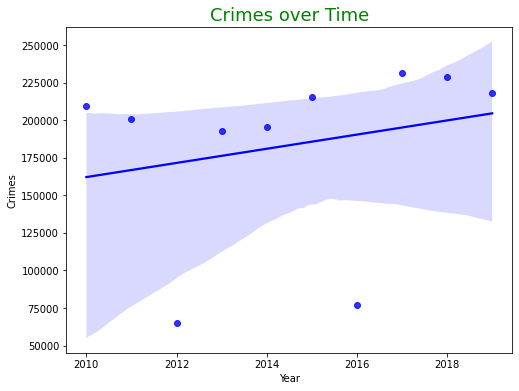

```python
import seaborn as sns
from sklearn import linear_model
from statsmodels.formula.api import ols

df = pandas.DataFrame()

df['Crimes'] = s
df['Year'] = t


plt.figure(figsize = (8, 6))
sns.regplot(x = "Year", y = "Crimes", data = df, color = 'blue')
plt.title('Crimes over Time',color = 'green', fontsize = '18')
plt.xlabel("Year")
plt.ylabel("Crimes")
```

```python
regression = ols(formula = 'Crimes ~ Year', data = df).fit()
print(regression.summary())
```

```
                            OLS Regression Results
==============================================================================
Dep. Variable:                 Crimes   R-squared:                       0.055
Model:                            OLS   Adj. R-squared:                 -0.063
Method:                 Least Squares   F-statistic:                    0.4681
Date:                Mon, 16 May 2022   Prob (F-statistic):              0.513
Time:                        17:07:41   Log-Likelihood:                -123.52
No. Observations:                  10   AIC:                             251.0
Df Residuals:                       8   BIC:                             251.6
Df Model:                           1
Covariance Type:            nonrobust
==============================================================================
                 coef    std err          t      P>|t|      [0.025      0.975]
------------------------------------------------------------------------------
Intercept  -9.312e+06   1.39e+07     -0.671      0.521   -4.13e+07    2.27e+07
Year        4713.5515   6889.554      0.684      0.513   -1.12e+04    2.06e+04
==============================================================================
Omnibus:                        6.370   Durbin-Watson:                   0.587
Prob(Omnibus):                  0.041   Jarque-Bera (JB):                3.196
Skew:                          -1.384   Prob(JB):                        0.202
Kurtosis:                       3.111   Cond. No.                     1.41e+06
==============================================================================

Notes:
[1] Standard Errors assume that the covariance matrix of the errors is correctly specified.
[2] The condition number is large, 1.41e+06. This might indicate that there are
strong multicollinearity or other numerical problems.
```

```python
regression.params
```

```
Intercept   -9.312092e+06
Year         4.713552e+03
dtype: float64
```

```python
# Checking the p value for correlation

from scipy.stats import spearmanr
s, p_value = spearmanr(df.Crimes.values, df.Year.values)
print('Statistic = %.4f, p = %.4f' % (s , p_value))
if p_value > 0.05:
    print('No correlation', p_value)
else:
    print('Correlated', p_value)
```

```
Statistic = 0.5515, p = 0.0984
No correlation 0.09840117666963498
```

# Final Insights

In this tutorial we looked at the following: 1) How to read data from a CSV file using pandas

2) How to clean and parse the databases

3) How to deal with missing data

4) How to create bargraphs and scatter plots

5) How to analyze the data using hypothesis testing and linear regression

6) How to plot/create visualizations of the linear regression

7) How to create interactive maps

# Limitations

One major limitation these datasets and our analysis has is the lack of evidence of causation. Our analysis looked at correlations and patterns observed, but does not dive into the possible causations of what the data recorded. This is incredibly important to note in data science: causation is NOT correlation. Another limitation we faced was dealing with missing or unknown data. For the most part, our analysis strayed away from dealing with any missing data. We were lucky that our dataset had data usually responsibly recorded. However, we did not use data that did not have a date and time recorded. Could there possibly be a correlation between not recorded date and time and certain crimes? Sure, but we did not choose to analyze that in our tutorial. Additionally, we looked at crimes that involved specific sexes. However, these datasets only acknowledged male and female sexes. Moreover, there were datasets that had sex listed as unknown. There are many ways of dealing with missing data. For more information visit the following links: http://pandas.pydata.org/pandas-docs/stable/missing_data.html https://cmsc320.github.io/files/SAMHSA_missing_values.pdf

In our analysis we deemed it best not to take any averages or make predictions about that missing data, but to only use the information given to us.